# 1. Розв'язання задачі комівояжера(№9)

```python
import itertools

# Граф у вигляді словника сусідства з вагами
edges = [(1,2,3), (1,3,5), (1,4,7), (2,3,6), (2,4,8), (3,4,9)]

# Створимо словник для зручного доступу до ваг ребер
graph = {}
for u, v, w in edges:
    graph[(u, v)] = w
    graph[(v, u)] = w  # бо граф неорієнтований

# Всі вершини графа
nodes = [1, 2, 3, 4]

min_path = None
min_cost = float('inf')

# Фіксуємо початкову вершину — 1
start = 1
# Перебираємо всі можливі перестановки інших вершин
for perm in itertools.permutations([n for n in nodes if n != start]):
    path = [start] + list(perm) + [start]  # замкнений цикл
    cost = 0
    for i in range(len(path) - 1):
        cost += graph[(path[i], path[i+1])]
    if cost < min_cost:
        min_cost = cost
        min_path = path

# Виведемо результат
print("Найкоротший маршрут:", min_path)
print("Його довжина:", min_cost)
```

```
Найкоротший маршрут: [1, 2, 3, 4, 1]
Його довжина: 25
```

## 2. Візуалізація графа

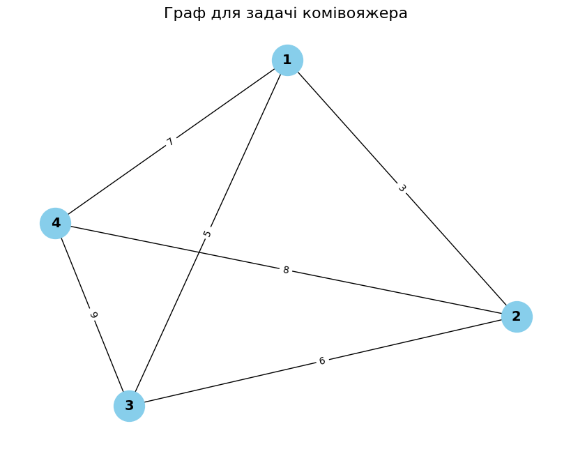

```python
import networkx as nx
import matplotlib.pyplot as plt

# Задані ребра у форматі (вузол1, вузол2, вага)
edges = [(1,2,3), (1,3,5), (1,4,7), (2,3,6), (2,4,8), (3,4,9)]

# Створимо граф
G = nx.Graph()
G.add_weighted_edges_from(edges)

# Побудова графа
pos = nx.spring_layout(G, seed=42)  # Автоматичне розташування вершин

plt.figure(figsize=(8, 6))
nx.draw(G, pos, with_labels=True, node_color='skyblue', node_size=1000, font_size=14, font_weight='bold')
nx.draw_networkx_edge_labels(G, pos, edge_labels={(u, v): d['weight'] for u, v, d in G.edges(data=True)})
plt.title("Граф для задачі комівояжера", fontsize=16)
plt.show()
```

# 3.Обґрунтування асимптотичної складності

**Алгоритм грубої сили**

- Асимптотика - $O(n!)$
- Генерує всі можливі перестановки вершин. Для $n$ вершин кількість перестановок дорівнює $(n-1)! / 2$. Найгірший випадок вимагає повного перебору всіх варіантів, що експоненційно зростає зі збільшенням $n$.

**Алгоритм найближчого сусіда**

- Асимптотика - $O(n^2)$
- На кожному кроці алгоритм вибирає найближчу вершину з $O(n$) кандидатів. Для $n$ вершин це призводить до $O(n^2)$ операцій.

## Відповіді на контрольні питання

**1.** Жадібний алгоритм - це алгоритм, який на кожному кроці робить локально оптимальний вибір, сподіваючись отримати глобально оптимальне рішення. Він завжди вибирає те, що виглядає найкращим зараз, без огляду на майбутні наслідки.

**2.** Головними принципами роботи жадібних алгоритмів є вибір без повернення, оптимальна підструктура та властивість жадібного вибору

**3.** Головною відмінністю між жадібними алгоритмами та динамічним програмуванням є те, що жадібні алгоритми роблять незворотній локально оптимальний вибір на кожному кроці, не розглядаючи інші можливості чи майбутні наслідки цього вибору.

**4.** За допомогою жадібних алгоритмів можна розв'язати наступні задачі:

- Пошук мінімального остовного дерева
- Побудова оптимального префіксного коду
- Задача про розподіл завдань
- Знаходження найкоротших шляхів у графах

**5.** У використанні жадібних алгоритмів може бути обмеження в неспроможності знайти глобально оптимальне рішення

**6.** Жадібні алгоритми часто використовуються для наближеного розв’язання, бо вони є дуже ефективними і мають низьку складність у порівнянні з точними методами.